# Medidas de forma

20/9/2021

## Medidas de forma

Se utilizan para describir dos características de la distribución de los datos:

- Simetría (o asímetria): miden la mayor o menor simetría (mayor o menor asimetría) de la distribución de los datos.
- Curtosis: miden la mayor o menor concentración de los datos alrededor de la media.

## Distribución simétrica

- Hay el mismo número de elementos a la izquierda y derecha de la media.
- La media, mediana y moda coinciden.
- ‘Forma de campana’ (distribución normal)

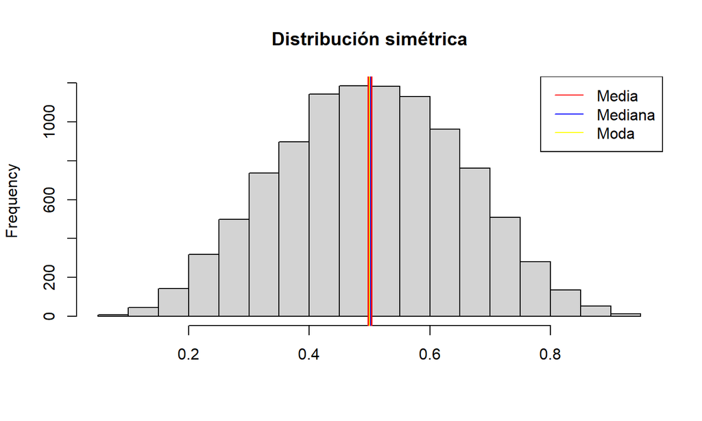

## Distribución asimétrica a la izquierda / negativa

- La cola izquierda de la distribución se alarga para los valores por debajo de la media.

[figure not shown]

## Distribución asimétrica a la derecha / positiva

- La cola derecha de la distribución se alarga para los valores por encima de la media.

[figure not shown]

## Coeficiente de asimetría de Fisher

\(g_1 = \frac{\frac{1}{n}\displaystyle\sum(x_i - \overline{x})^3 * n_i }{(\frac{1}{n}\displaystyle\sum(x_i - \overline{x})^3 * n_i)^{3/2}}\)

Donde:  
\(g_1:\) coeficiente de asimetría de Fisher.  
\(\overline{x}:\) media de los datos.  
\(n_i:\) frecuencia de cada valor.

\(g_1 = 0:\) Distribución simétrica.  
\(g_1 < 0:\) Asimétrica negativa.  
\(g_1 > 0:\) Asimétrica positiva.

## Kurtosis

Estima el grado de concentración de los datos alrededor de la zona central de la distribución.

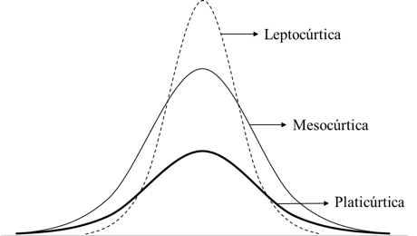

Leptocúrtica: gran concentración de valores alrededor de la media.  
Mesocúrtica: concentración ‘normal’ de valores alrededor de la media.  
Platicúrtica: baja concentración de valores alrededor de la media.

## Coeficiente de curtosis

\(g_2 = \frac{\frac{1}{n}\displaystyle\sum(x_i - \overline{x})^4 * n_i }{(\frac{1}{n}\displaystyle\sum(x_i - \overline{x})^2 * n_i)^2} - 3\)

Donde:  
\(g_2:\) coeficiente de curtosis.  
\(\overline{x}:\) media de los datos.  
\(n_i:\) frecuencia de cada valor.

\(g_2 = 0:\) distribución mesocúrtica.  
\(g_2 > 0:\) distribución leptocúrtica.  
\(g_2 < 0:\) distribución platicúrtica.

## Teorema de Chebyshev

Dado un número *k* mayor o igual a 1 y un conjunto de *n* mediciones, al menos \(1-(\frac{1}{k^2})\) de las mediciones estarán dentro de *k* desviaciones estándar de su media.

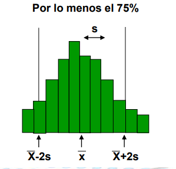

Teorema: proposición matemática demostrable a partir de axiomas o de proposiciones ya demostradas.

Chebyshev: matemático ruso (1821 - 1894).

## Teorema de Chebyshev: ejemplo

Interjet tiene estimado que en promedio, en cada vuelo transporta 53.82 pasajeros, con una desviación estándar de 10.18.

¿Qué porcentaje de los vuelos de interjet están dentro de *k=2* desviaciones estándar de la media y cuál es dicho intervalo de pasajeros?

1. Calcular los límites del intervalo para +/- dos desviaciones estándar.
2. Aplicar la fórmula del teorema de Chebyshev.

## Regla empírica

Para distribuciones normales, tenemos la siguiente regla empírica:

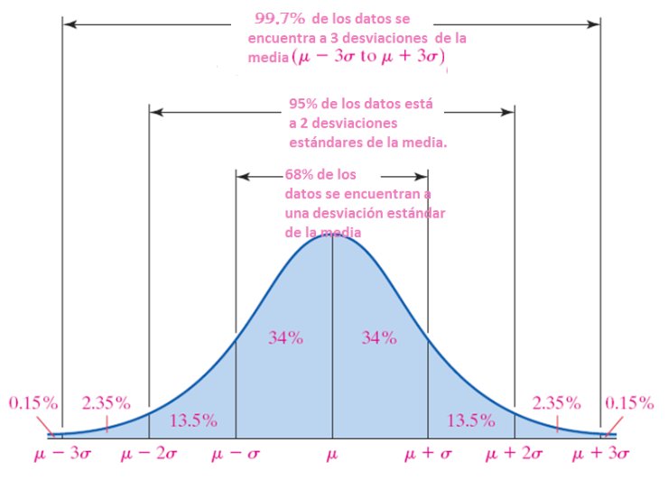